# Ford Go-Bike Data

## by Mehmet Cenk Bursali

## Investigation Overview

In this investigation, I wanted to look at the different features of Ford Go-Bike system that could affect rent duration. The main focus was hours, weekdays, gender and age.

## Dataset Overview

The dataset contains 183412 rental transactions and their 16 features. Rent duration, start-end times, locaiton and name of start-end stations, gender and age of members are given. Over a thousand lines were removed from the analysis due to inconsistencies or missing information.

## Distribution of Bike Rent Periods

Bike rent durations in the dataset take on a very large range of values, from about 61 seconds at the shortest to about a few hours at the longest. Plotted on a logarithmic scale, the distribution of durations takes on a uniimodal shape.

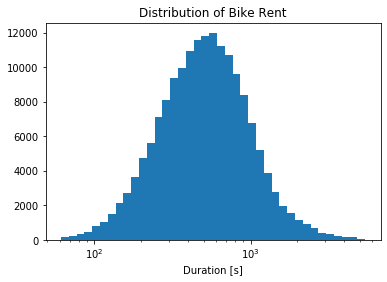

```python
bins = 10**np.arange(np.log10(df1['duration_sec']).min(), np.log10(5000).max()+.05, .05)

plt.hist(data=df1.query('duration_sec<5000'), x='duration_sec', bins=bins)
plt.xscale('log')
plt.xlabel('Duration [s]')
plt.title('Distribution of Bike Rent');
```

## Counts in Days of Week

Data is from February, 2019. Because of february in 2019 is 28 days, each week day falls into this month 4 times.

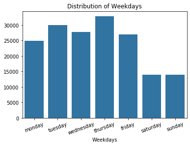

```python
base_color = sb.color_palette()[0]
sb.countplot(df1['day_in_week'], color=base_color)
plt.xticks(rotation=20)
plt.ylabel("")
plt.xlabel("Weekdays");
plt.title('Distribution of Weekdays');
```

## Duration vs. Distance

Longitudes and latitudees of start and end stations are given in the dataset. Using this, air distance between start and end stations can be calculated. Plotting duration and distance in a linear scale produces an approximately linear relationship. This can mean that people use bikes for transportation more than touring.

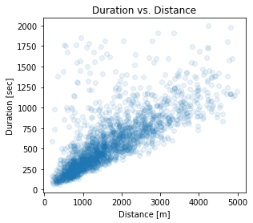

```python
plt.figure(figsize=(10,4))
plt.subplot(121)
plt.scatter(data=df1.query('5000>distance>0 and duration_sec<2000').sample(2000), x='distance', y='duration_sec', alpha=.1)
plt.title('Duration vs. Distance')
plt.xlabel('Distance [m]')
plt.ylabel('Duration [sec]');
```

## Bike Share for All Trip program in east region

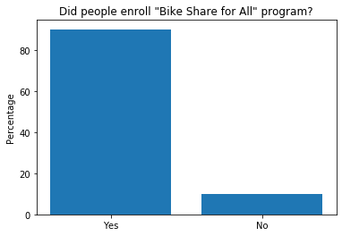

```python
plt.bar(df1['bike_share_for_all_trip'].unique(), df1['bike_share_for_all_trip'].value_counts(sort=False)/len(df1)*100)
plt.title('Did people enroll "Bike Share for All" program?')
plt.ylabel('Percentage');
```

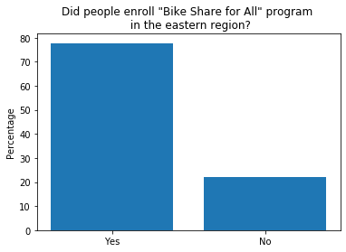

```python
plt.bar(sorted(df1.query('regions=="east"')['bike_share_for_all_trip'].unique(), reverse=True),
        df1.query('regions=="east"')['bike_share_for_all_trip'].value_counts()/len(df1.query('regions=="east"'))*100);
plt.title('Did people enroll "Bike Share for All" program \n in the eastern region?')
plt.ylabel('Percentage');
```